# IODS course project

Pinky Dutta

# Introduction to Open Data Science - Course Project

# About the project

#### PHD-302 Introduction to Open Data Science

##### How I found about the course?

While browsing through the MOOC pages, I came across the “Introduction to Open Data Science” course. It grabbed my attention as it caters the to the basis of R, and I am interested in learning the language.

**Link to my GitHub repository** https://github.com/pdutta11/IODS-project

# Chapter 2: Regression Analysis

### About the data

In this exercise we are going to analyze student’s attitude towards statistics, based on the survey conducted in 2014. The initial survey was conducted in Finnish and was measured on the [Likert Scale](https://en.wikipedia.org/wiki/Likert_scale)(1-5).

For the analysis, we convert the original data to a tabular format where each column represents questions and rows contain individual response from the participants. The items of the central measure are named so that the connections to the corresponding dimensions (Deep/SUrface/STrategic) can be easily seen. The analysis will be carried across 7 variables: “age”, “gender”, “attitude”, “deep”, “strategic”, “surface” and “points” distributed in 7 columns and on 166 student observations.

More information on data can be found [here](https://www.mv.helsinki.fi/home/kvehkala/JYTmooc/JYTOPKYS3-meta.txt).

```r
date()
```

```
## [1] "Fri Nov 06 04:24:51 2020"
```

##### *Before we beging (setup):*

```r
# Setting up working directory of R session into IODS project folder
setwd("~/Workspace/r-studio-projects/IODS-project")

#read data into memory
students2014 <- read.table("./Data/learning2020.table", header=TRUE)

#Structure of the data
str(students2014)
```

```
## 'data.frame':    166 obs. of  7 variables:
##  $ gender  : chr  "F" "M" "F" "M" ...
##  $ Age     : int  53 55 49 53 49 38 50 37 37 42 ...
##  $ Attitude: int  37 31 25 35 37 38 35 29 38 21 ...
##  $ deep    : num  3.58 2.92 3.5 3.5 3.67 ...
##  $ stra    : num  3.38 2.75 3.62 3.12 3.62 ...
##  $ surf    : num  2.58 3.17 2.25 2.25 2.83 ...
##  $ Points  : int  25 12 24 10 22 21 21 31 24 26 ...
```

```r
#Dimension of the data
dim(students2014)
```

```
## [1] 166   7
```

```r
library(GGally)
```

```r
library(ggplot2)
```

#### **Overview of data (in graph form)**

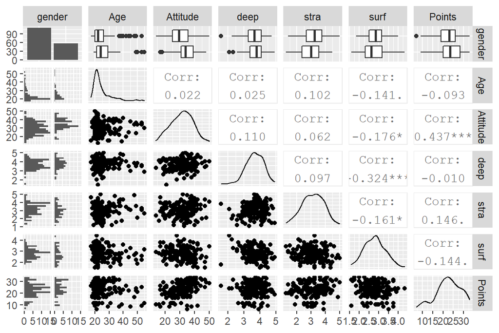

```r
p <- ggpairs(students2014, mapping = aes(), lower = list(combo = wrap("facethist", bins = 20)))
p
```

#### **Regression analysis across *age - deep - exam points***

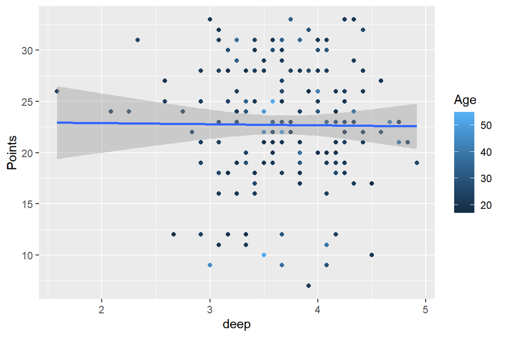

```r
g1 <- ggplot(students2014, aes(x = deep, y = Points, col = Age))
g2 <- g1 + geom_point()
g3 <- g2 + geom_smooth(method = "lm")
g3
```

```r
my_model <- lm(Points ~ Age + deep, data = students2014)

summary(my_model)
```

```
##
## Call:
## lm(formula = Points ~ Age + deep, data = students2014)
##
## Residuals:
##      Min       1Q   Median       3Q      Max
## -16.0157  -3.8026   0.1145   4.6511  10.8175
##
## Coefficients:
##             Estimate Std. Error t value Pr(>|t|)
## (Intercept) 24.82368    3.40367   7.293 1.25e-11 ***
## Age         -0.07059    0.05921  -1.192    0.235
## deep        -0.08315    0.82984  -0.100    0.920
## ---
## Signif. codes:  0 '***' 0.001 '**' 0.01 '*' 0.05 '.' 0.1 ' ' 1
##
## Residual standard error: 5.905 on 163 degrees of freedom
## Multiple R-squared:  0.008745,   Adjusted R-squared:  -0.003417
## F-statistic: 0.719 on 2 and 163 DF,  p-value: 0.4888
```

(more chapters to be added similarly as we proceed with the course!)